# 00b. Supplementary figures

Supplement-figure assembler for the chromlearn project. Each section below produces one supplementary figure (PDF + 600 dpi PNG) backing the main-text claims in `00_main_figure.py`: per-cell breakdowns of the pole-velocity fit and its f_pp / f_cp non-identifiability, forecast error vs horizon, sensitivity to basis size, smoothness penalty, and Itô vs Stratonovich estimator, and characteristic spatial and temporal scales of the drift-vs-diffusion comparison.

## Publication style

Mirrors the main-text notebook so figures are consistent across the paper.

## Configuration

Canonical configuration matching the main figure.

```
Chrom-chrom pair-distance 1%-quantile = 1.148 um
Loaded 12 rpe18_ctr cells (frac=0.4).
```

## Helpers for Fig S1 (pole-velocity pp+cp model)

The pp+cp pole-velocity model lives outside `chromlearn.model_fitting` (which fits chromosome dynamics, not pole dynamics). We inline the minimal machinery needed for the per-cell kernel fits and the constrained-share refit sweep.

## Fig S1. Per-cell pp/cp kernels and partition non-identifiability

```
Fig S1: building pole-velocity feature rows...
```

```
Fig S1 (c): running constrained-share sweep over 11 targets...
```

```
Saved figS1_pp_cp_kernels_partition.pdf and figS1_pp_cp_kernels_partition.png
```

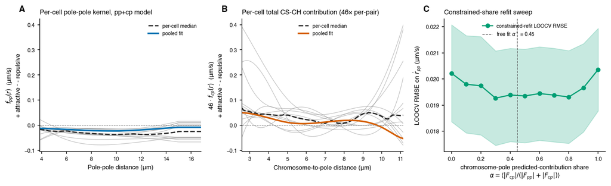

Fig S1. The pp+cp pole-velocity model cannot separately identify the f_pp and f_cp kernels. (A) Per-cell f_pp(r) from individual pp+cp fits (grey lines), with the per-cell median (dashed) and the pooled fit (blue) overlaid. (B) Per-cell 46·f_cp(r), the per-pair chromosome-to-pole contribution scaled by the typical chromosome count, on the same y-axis as (A) for direct scale comparison. The 46x value sums radial-magnitude contributions and so overstates the actual chromosome contribution to pole velocity. (C) Constrained-share refit sweep on the spindle-elongation velocity: at each target chromosome-pole share alpha = <|F_cp| / (|F_pp| + |F_cp|)>, the pp+cp model is refit with alpha held to that value and held-out LOOCV RMSE on the elongation velocity is recomputed. The curve is flat across alpha, which means many different (f_pp, f_cp) splits fit the data equally well. The unconstrained free-fit alpha* is marked as a vertical reference.

- The pp+cp pole-velocity regression lives outside the `chromlearn.model_fitting` chromosome-dynamics pipeline, since here we are predicting pole motion rather than chromosome motion. The minimal design-matrix code is inlined in this notebook above.
- Each per-cell fit uses the same B-spline basis and roughness penalty as the pooled fit. Under-determined cells produce noisier curves; the pooled fit averages over cells.
- The 46x scaling on f_cp matches main Fig 2 panel B and converts the per-pair kernel into the per-pole total a centrosome experiences from the chromosome ensemble.
- Constrained-share construction: for a target alpha in [0, 1] we minimize the pole-velocity residual subject to a smooth equality constraint that enforces the predicted-share to that target. The sweep traces a continuous family of (alpha f_pp, (1 - alpha) f_cp) refits.
- Why the curve is flat rather than convex: pp+cp is a near-collinear regression on pole velocity; many (f_pp, f_cp) pairs fit equally well in a least-squares sense. The free-fit alpha* lies inside the flat region. Mild regularization by the structural constraint can even push the constrained sweep slightly below the free-fit RMSE, well within fold-to-fold SE; we do not plot a free-fit horizontal baseline because the dip would invite overinterpretation.
- The non-identifiability means |F_cp| should not be quoted as a separately meaningful biological force. The Fig 2 panel C comparison establishes that an inter-pole term is required; this panel shows that the f_pp / f_cp split inside the joint fit is not separately recoverable from this data.

## Fig S2. LOOCV path MSE vs window length and per-cell path MSE

```
Fig S2: rollout LOOCV across 4 topologies, 0..630 s (126 frames at dt=5 s)...
  poles...
```

```
  center...
```

```
  poles_and_chroms_enveloped...
```

```
  poles_and_chroms...
```

```
Saved figS2_forecast_horizon.pdf and figS2_forecast_horizon.png
```

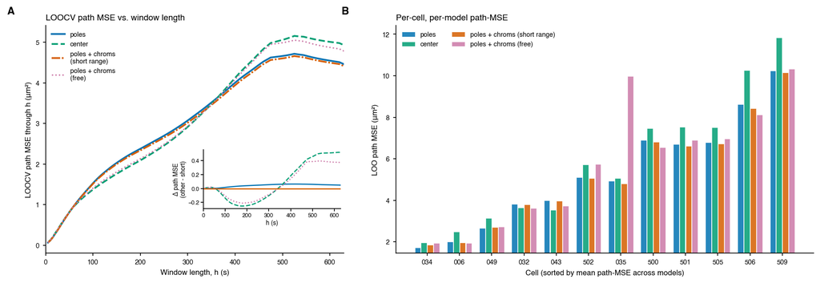

Fig S2. The main-text topology selection holds at every window length once enough frames are integrated. (A) LOOCV path MSE computed on the trimmed window cut at h frames, plotted against h, for the same four topologies as in main Fig 3. Each curve is the running average of per-frame ensemble MSE; at h = trim-window length the curve approaches the path MSE shown in Fig 3 panel C. The inset plots each topology's path-MSE-through-h minus the short- range value, so the topology ordering as the window grows is visible despite the absolute curves nearly coinciding. (B) Per- cell path MSE (LOOCV) for the same four topologies, with cells sorted by mean path MSE across models.

## Fig S3. Sensitivity to basis size, smoothness penalty, and Itô vs Stratonovich

```
Fig S3 (a) col 1: n_basis sweep at lambda_rough=1e+00 (3 fits)...
  n_basis=4
```

```
  n_basis=10
```

```
  n_basis=30
```

```
Fig S3 (a) col 2: lambda_rough sweep at n_basis=10 (3 fits)...
  lambda_rough=1e-01
```

```
  lambda_rough=1e+00
```

```
  lambda_rough=1e+01
```

```
Fig S3 (b): rerunning rollout for Itô / Stratonovich...
```

```
Saved figS3_hyperparam_sensitivity.pdf and figS3_hyperparam_sensitivity.png
```

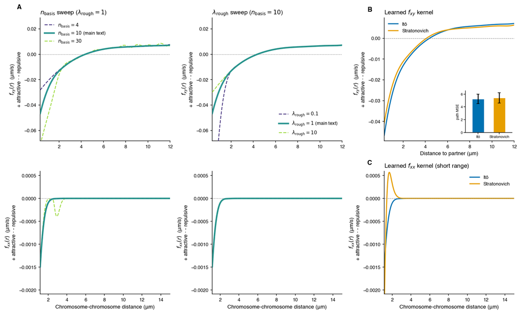

Fig S3. The selected short-range force kernels are stable to the main fitting choices: basis size, smoothness penalty, and Itô vs Stratonovich estimator. (A) Independent sweeps of n_basis in {4, 10, 30} (left column) and lambda_rough in {0.1, 1, 10} (right column) on the poles_and_chroms_enveloped topology, with the other parameter held at its main-text value. Top row is the chromosome-to-pole kernel f_xy(r); bottom row is the chromosome-chromosome kernel f_xx(r). A sequential viridis colormap encodes parameter ordering (low to high, dark to light); the main-text value is drawn as a bold solid line. (B) f_xy(r) from the pooled fit under Ito vs Stratonovich estimators; the inset shows held-out path MSE under each convention. (C) The corresponding f_xx(r) under the two conventions.

## Fig S4. Per-cell kernels for the selected topology

```
Fig S4: pooled fit + bootstrap...
```

```
[Parallel(n_jobs=-1)]: Using backend LokyBackend with 16 concurrent workers.
```

```
[Parallel(n_jobs=-1)]: Done  18 tasks      | elapsed:    8.0s
```

```
[Parallel(n_jobs=-1)]: Done 100 out of 100 | elapsed:   23.1s finished
```

```
Fig S4: per-cell fits...
```

```
Saved figS4_percell_kernels.pdf and figS4_percell_kernels.png
```

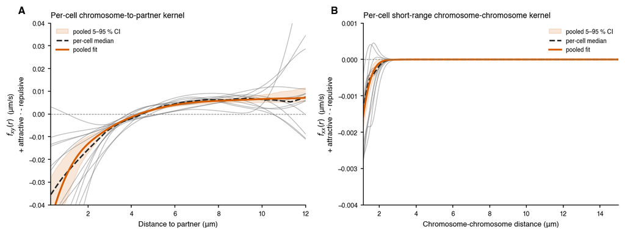

Fig S4. Cell-to-cell variability in the learned force kernels. Per-cell f_xy(r) (left) and f_xx(r) (right) from individual fits of the selected short-range topology, one line per cell, overlaid on the pooled bootstrap 5-95 % CI band. The f_xx panel is truncated at the 1%-quantile of observed chromosome-chromosome distances so that only the data-supported short-range portion of the kernel is shown.

## Fig S5. Drift-vs-diffusion sensitivity and characteristic scales

```
Fig S5: drift-vs-diffusion sensitivity sweep...
```

```
Saved figS5_drift_diffusion_sensitivity.pdf and figS5_drift_diffusion_sensitivity.png
```

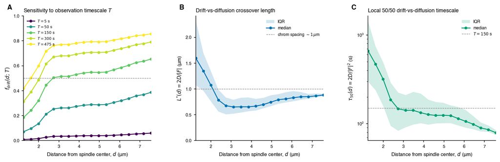

- The T sweep includes the per-step dt = 5 s as a lower bound, the main-text T = 150 s, and the per-cell trimmed-window length T_obs ~ 475 s as an upper bound. The intermediate values 50 and 300 s bracket the main-text choice.
- L* and tau_50 give the same drift-vs-diffusion comparison as f_drift, in raw length and time units rather than as a bounded fraction. L* anchors the comparison to biological length scales (chromosome spacing); tau_50 anchors it to the steady-elongation duration.
- L* is below ~1 um across most of the spindle interior, meaning drift dominates already at sub-chromosome-spacing scales. This is the spatial counterpart to f_drift > 0.5.
- tau_50 is mostly below ~150 s, the main-text accumulation window. This means a typical chromosome's drift signal becomes detectable well within the steady-elongation phase even where f_drift is not already close to 1.
- All three panels are computed per chromosome per frame, then median- and IQR-binned by spindle-center distance d, with bins below 30 observations masked; this matches the estimator used in main Fig 4. Panel A traces the bin-median curve for each T and omits the IQR band to keep the sweep readable.